# Hoemwork 4

Alejandro Rosales

October 3, 2019

**PROBLEM 1**

**PART 1 Q1** Construct a scatterplot with median age on the x-axis and the percentage of people who voted for Trump on the y-axis. Describe the relationship you see.

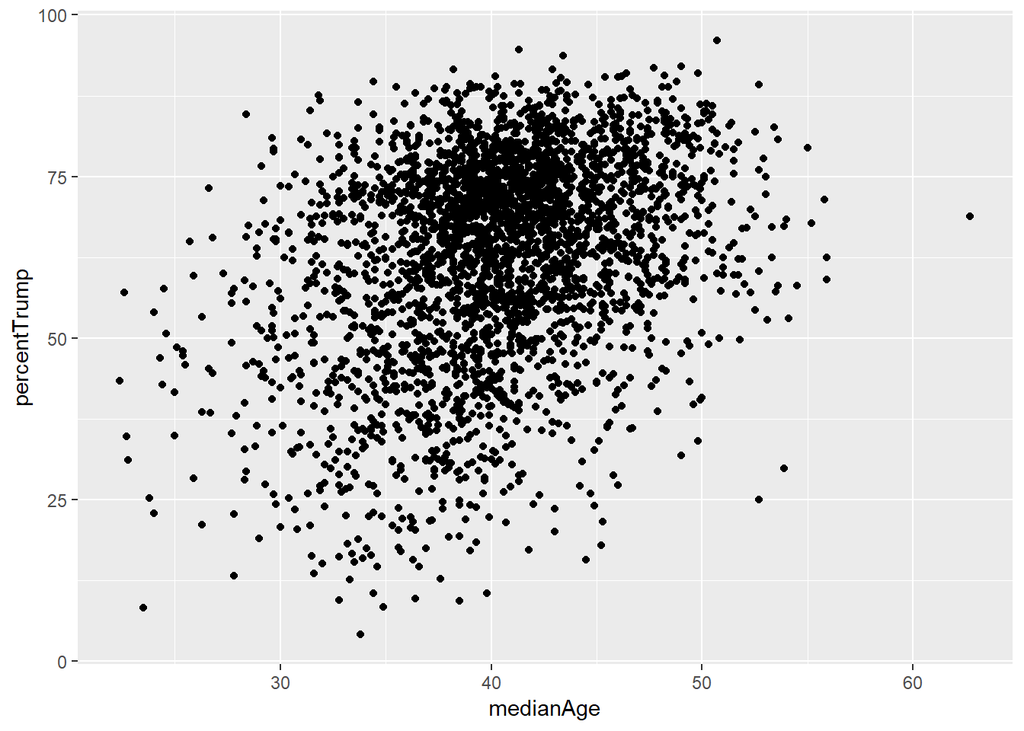

```r
election2016 <- read.csv("election2016.csv")

ggplot() +
  geom_point(aes(x=medianAge, y=percentTrump), data=election2016)
```

**PART 1 Q2** Fit a simple linear regression model where the response is the percentage of people who voted for Trump and the predictor is median age. Construct residual diagnostic plots of that fit. Do there appear to be any assumption violations?

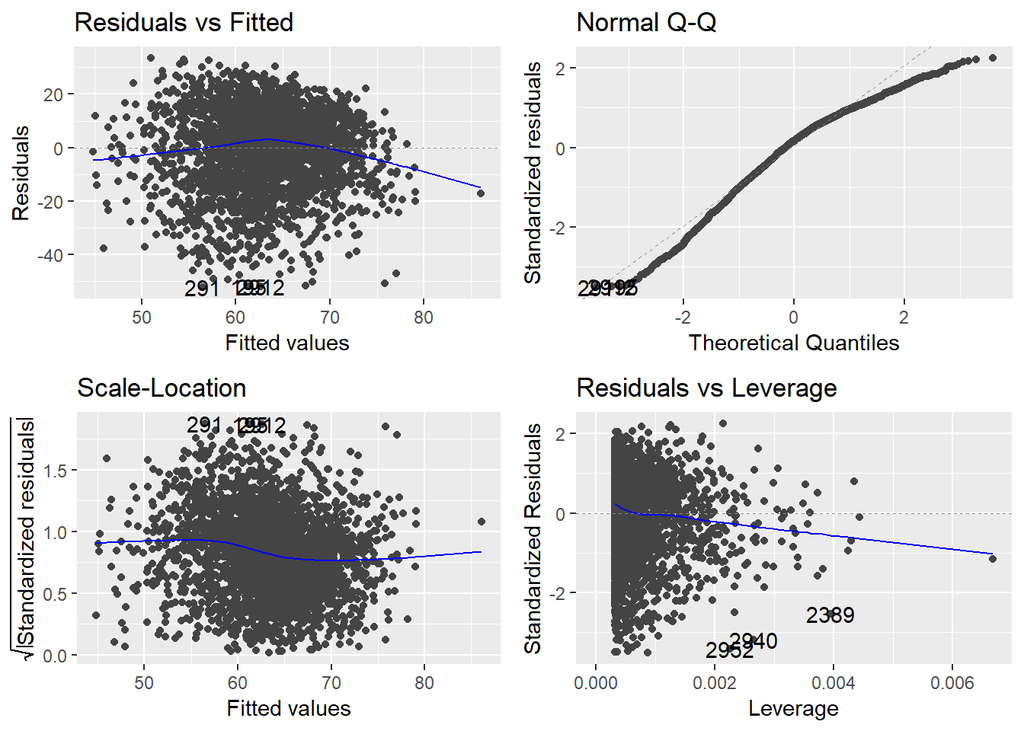

```r
election2016fit <- lm(percentTrump ~ medianAge, data=election2016)
autoplot(election2016fit)
```

The residual vs fitted trend line does not appear to be too straihgt and the QQ-plot data points seem to follow a slight arch

**PART 1 Q3** Use a Box-Cox plot to determine whether a transformation of the response variable could improve the model fit. If the plot suggests a transformation, fit the model with that transformation and comment on the residual diagnostic plots for that model. Does it make sense to do a transformation?

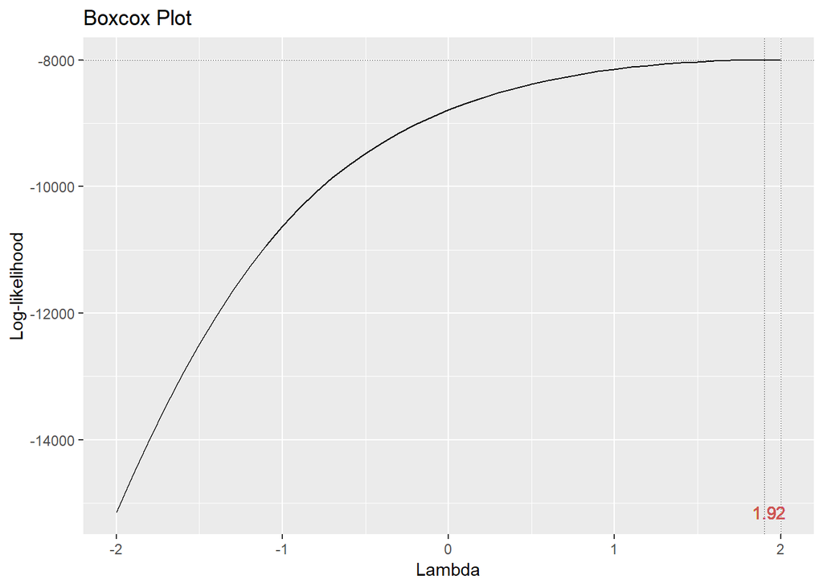

```r
gg_boxcox(election2016fit)
```

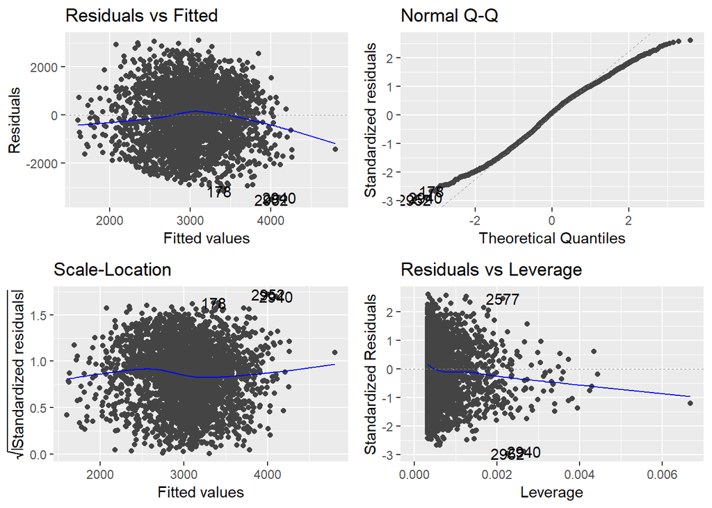

```r
election2016fit <- lm(percentTrump ^ 1.92 ~ medianAge, data=election2016)
autoplot(election2016fit)
```

The residual vs fitted trend line does not appear to have improved while the QQ-plot very slightly imporved but not enough to keep the transfromation. So no it does not make sense.

**PART 1 Q4** Check the model summary for the model in part 2. What percent of the variability in voting rates is explained by median age? (Reference specific output).

```r
election2016fit <- lm(percentTrump ~ medianAge, data=election2016)
summary(election2016fit)
```

```
##
## Call:
## lm(formula = percentTrump ~ medianAge, data = election2016)
##
## Residuals:
##     Min      1Q  Median      3Q     Max
## -52.417  -9.298   2.517  10.984  33.588
##
## Coefficients:
##             Estimate Std. Error t value Pr(>|t|)
## (Intercept) 21.92201    2.15947   10.15   <2e-16 ***
## medianAge    1.02323    0.05309   19.27   <2e-16 ***
## ---
## Signif. codes:  0 '***' 0.001 '**' 0.01 '*' 0.05 '.' 0.1 ' ' 1
##
## Residual standard error: 14.87 on 3111 degrees of freedom
## Multiple R-squared:  0.1067, Adjusted R-squared:  0.1064
## F-statistic: 371.5 on 1 and 3111 DF,  p-value: < 2.2e-16
```

In this model, 10.64% of the variability can be explained by median age.

**PART 1 Q5** Is median age a significant predictor of the voting rates? (Reference specific output).

Yes, because the p-value for medianAge is <2e-16 which tells you the multiplier is signifcant. Also for a single variable, it can explain 10% variabilty.

**PART 1 Q6** Interpret the coefficient for median age in the context of the data.

For every 1 year increase in the median age, percentTrump increases by 1.02323.

**PROBLEM 2**

Construct a scatterplot matrix for the variables in this data. Describe/discuss any associations you see with the response variable.

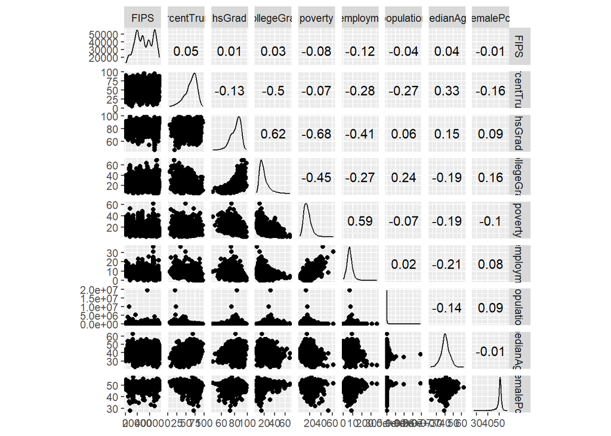

```r
ggscatmat(election2016)
```

Fit a multiple regression model with where the response is the percentage of people who voted for Trump and the predictors are all of the demographic variables in the data set. Construct residual diagnostic plots of that fit. Do there appear to be any assumption violations?

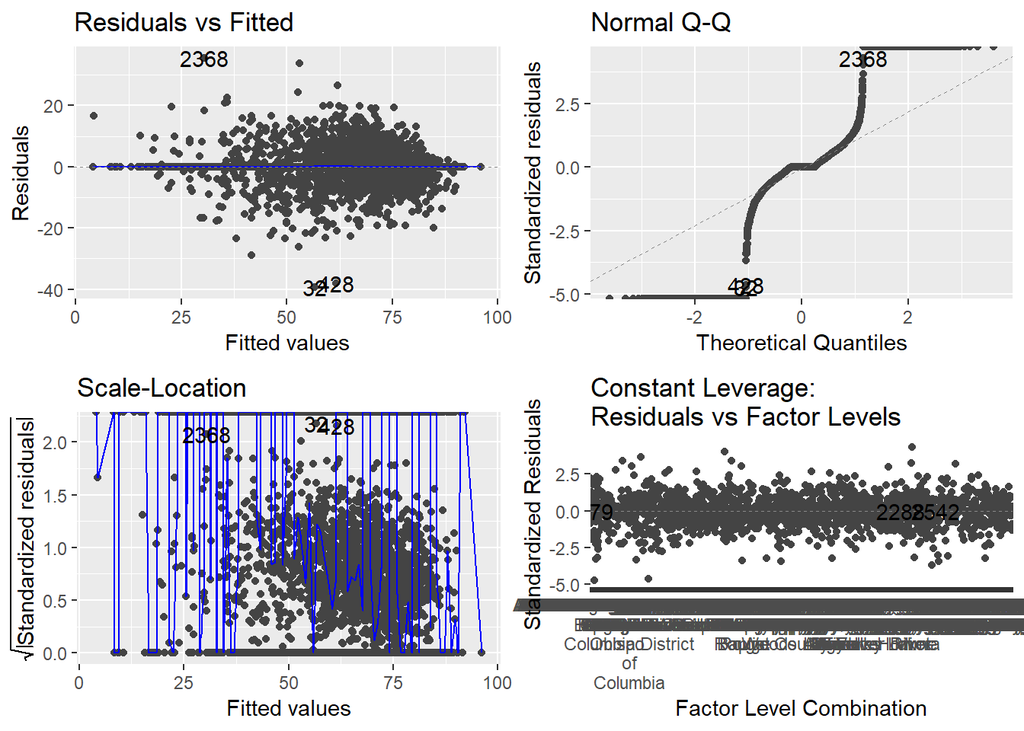

```r
election2016fit2 <- lm(percentTrump ~ state + county + FIPS + hsGrad + collegeGrad + poverty + unemployment + population + medianAge + femalePct, data=election2016)
autoplot(election2016fit2)
```

Determine if the fitted model in part 2 is a significant model to predict voting rates. (Reference specific output).

```r
summary(election2016fit2, include=FALSE)
```

```
##
## Call:
## lm(formula = percentTrump ~ state + county + FIPS + hsGrad +
##     collegeGrad + poverty + unemployment + population + medianAge +
##     femalePct, data = election2016)
##
## Residuals:
##     Min      1Q  Median      3Q     Max
## -39.430  -0.691   0.000   1.072  35.529
##
## Coefficients: (2 not defined because of singularities)
##                              Estimate Std. Error t value Pr(>|t|)
## (Intercept)                 1.333e+02  1.348e+01   9.891  < 2e-16 ***
## stateArizona               -4.799e+00  1.634e+01  -0.294 0.768986
## stateArkansas               2.459e+01  2.022e+01   1.216 0.224311
## stateCalifornia             2.260e+01  2.531e+01   0.893 0.372064
## stateColorado               4.374e+01  3.535e+01   1.237 0.216185
## stateConnecticut            4.610e+01  4.041e+01   1.141 0.254171
## stateDelaware               4.985e+01  4.543e+01   1.097 0.272709
## stateDistrict of Columbia   2.657e+01  5.160e+01   0.515 0.606677
## stateFlorida                7.245e+01  5.539e+01   1.308 0.191140
## stateGeorgia                7.733e+01  6.084e+01   1.271 0.203991
## stateHawaii                 4.217e+01  7.135e+01   0.591 0.554624
## stateIdaho                  9.700e+01  7.544e+01   1.286 0.198775
## stateIllinois               1.023e+02  8.064e+01   1.268 0.204908
## stateIndiana                1.109e+02  8.559e+01   1.295 0.195407
## stateIowa                   1.076e+02  9.072e+01   1.186 0.235943
## stateKansas                 1.261e+02  9.572e+01   1.317 0.188028
## stateKentucky               1.387e+02  1.009e+02   1.375 0.169425
## stateLouisiana              1.443e+02  1.055e+02   1.367 0.171779
## stateMaine                  1.272e+02  1.104e+02   1.152 0.249624
## stateMaryland               1.416e+02  1.155e+02   1.226 0.220443
## stateMassachusetts          1.410e+02  1.200e+02   1.175 0.240348
## stateMichigan               1.597e+02  1.259e+02   1.268 0.204904
## stateMinnesota              1.585e+02  1.308e+02   1.211 0.225952
## stateMississippi            1.770e+02  1.357e+02   1.304 0.192631
## stateMissouri               1.904e+02  1.411e+02   1.350 0.177260
## stateMontana                1.909e+02  1.458e+02   1.309 0.190757
## stateNebraska               1.999e+02  1.511e+02   1.324 0.185910
## stateNevada                 2.004e+02  1.558e+02   1.286 0.198686
```

[output cut: 1830 more lines]

```
## countyZiebach               3.227e+01  1.305e+01   2.474 0.013508 *
## FIPS                       -6.609e-03  5.030e-03  -1.314 0.189069
## hsGrad                     -1.682e-01  7.172e-02  -2.345 0.019198 *
## collegeGrad                -7.429e-01  5.343e-02 -13.904  < 2e-16 ***
## poverty                    -6.831e-01  6.957e-02  -9.819  < 2e-16 ***
## unemployment               -1.113e+00  1.235e-01  -9.017  < 2e-16 ***
## population                 -8.269e-06  1.171e-06  -7.064 2.69e-12 ***
## medianAge                   4.643e-01  6.399e-02   7.257 6.96e-13 ***
## femalePct                  -4.206e-01  1.322e-01  -3.182 0.001501 **
## ---
## Signif. codes:  0 '***' 0.001 '**' 0.01 '*' 0.05 '.' 0.1 ' ' 1
##
## Residual standard error: 8.779 on 1248 degrees of freedom
## Multiple R-squared:  0.8751, Adjusted R-squared:  0.6887
## F-statistic: 4.693 on 1864 and 1248 DF,  p-value: < 2.2e-16
```

With a F statisitic of 4.693 on 1864 and 1248 degree’s of freedom, p-value: < 2.2e-16 we have significant evidence that at least one βi≠0.

What percentage of the variability in voting rates is explained by this model? (Reference specific output).

68.87% of the variability in the response variable can be explained by the linear model.

Which demographic variables are significant predictors of voting rates?

Interpret the coefficient for median age in the context of the data. Why is this coefficient different than the one in Problem 1 (Part 6)?

For every 1 year increase in the median age, percentTrump increases by .4643. The number is different becasue now you are taking into account all the variables.